# CS_02_BELLABEAT

RJLD

2025-04-08

#INSTALL & LOAD PACKAGES Install the following packages first before running install.packages(“tidyverse”) install.packages(“here”) install.packages(“janitor”) install.packages(“skimr”) install.packages(“dplyr”) install.packages(“lubridate”) install.packages(“hms”)

```r
library(tidyverse)
library(here)
library(janitor)
library(skimr)
library(dplyr)
library(lubridate)
library(hms)
```

#LOAD DATASET & DATA EXPLORE & VISUALIZE ##DAILY ###DAILY-LOAD

```r
daily_activity_A <- read.csv("D:/Users/rjlde/Documents/+STUDY FILES+/2025 CASE STUDIES/CASE STUDY 2/RPROJ/CSV/DAILY/dailyActivity_merged_3.12.16-4.11.16.csv", stringsAsFactors = FALSE)
daily_activity_B <- read.csv("D:/Users/rjlde/Documents/+STUDY FILES+/2025 CASE STUDIES/CASE STUDY 2/RPROJ/CSV/DAILY/dailyActivity_merged_4.12.16-5.12.16.csv", stringsAsFactors = FALSE)
sleep_day_B <- read.csv("D:/Users/rjlde/Documents/+STUDY FILES+/2025 CASE STUDIES/CASE STUDY 2/RPROJ/CSV/DAILY/sleepDay_merged_4.12.16-5.12.16.csv", stringsAsFactors = FALSE)
```

###DAILY-CLEAN head()

```r
head(daily_activity_A)
```

```
##           Id ActivityDate TotalSteps TotalDistance TrackerDistance
## 1 1503960366    3/25/2016      11004          7.11            7.11
## 2 1503960366    3/26/2016      17609         11.55           11.55
## 3 1503960366    3/27/2016      12736          8.53            8.53
## 4 1503960366    3/28/2016      13231          8.93            8.93
## 5 1503960366    3/29/2016      12041          7.85            7.85
## 6 1503960366    3/30/2016      10970          7.16            7.16
##   LoggedActivitiesDistance VeryActiveDistance ModeratelyActiveDistance
## 1                        0               2.57                     0.46
## 2                        0               6.92                     0.73
## 3                        0               4.66                     0.16
## 4                        0               3.19                     0.79
## 5                        0               2.16                     1.09
## 6                        0               2.36                     0.51
##   LightActiveDistance SedentaryActiveDistance VeryActiveMinutes
## 1                4.07                       0                33
## 2                3.91                       0                89
## 3                3.71                       0                56
## 4                4.95                       0                39
## 5                4.61                       0                28
## 6                4.29                       0                30
##   FairlyActiveMinutes LightlyActiveMinutes SedentaryMinutes Calories
## 1                  12                  205              804     1819
## 2                  17                  274              588     2154
## 3                   5                  268              605     1944
## 4                  20                  224             1080     1932
## 5                  28                  243              763     1886
## 6                  13                  223             1174     1820
```

```r
head(daily_activity_B)
```

```
##           Id ActivityDate TotalSteps TotalDistance TrackerDistance
## 1 1503960366    4/12/2016      13162          8.50            8.50
## 2 1503960366    4/13/2016      10735          6.97            6.97
## 3 1503960366    4/14/2016      10460          6.74            6.74
## 4 1503960366    4/15/2016       9762          6.28            6.28
## 5 1503960366    4/16/2016      12669          8.16            8.16
## 6 1503960366    4/17/2016       9705          6.48            6.48
##   LoggedActivitiesDistance VeryActiveDistance ModeratelyActiveDistance
## 1                        0               1.88                     0.55
## 2                        0               1.57                     0.69
## 3                        0               2.44                     0.40
## 4                        0               2.14                     1.26
## 5                        0               2.71                     0.41
## 6                        0               3.19                     0.78
##   LightActiveDistance SedentaryActiveDistance VeryActiveMinutes
## 1                6.06                       0                25
## 2                4.71                       0                21
## 3                3.91                       0                30
## 4                2.83                       0                29
## 5                5.04                       0                36
## 6                2.51                       0                38
##   FairlyActiveMinutes LightlyActiveMinutes SedentaryMinutes Calories
## 1                  13                  328              728     1985
## 2                  19                  217              776     1797
## 3                  11                  181             1218     1776
## 4                  34                  209              726     1745
## 5                  10                  221              773     1863
## 6                  20                  164              539     1728
```

```r
head(sleep_day_B)#replace daily_activity_A w/ daily_activity_B and w/ sleep_day_B
```

```
##           Id              SleepDay TotalSleepRecords TotalMinutesAsleep
## 1 1503960366 4/12/2016 12:00:00 AM                 1                327
## 2 1503960366 4/13/2016 12:00:00 AM                 2                384
## 3 1503960366 4/15/2016 12:00:00 AM                 1                412
## 4 1503960366 4/16/2016 12:00:00 AM                 2                340
## 5 1503960366 4/17/2016 12:00:00 AM                 1                700
## 6 1503960366 4/19/2016 12:00:00 AM                 1                304
##   TotalTimeInBed
## 1            346
## 2            407
## 3            442
## 4            367
## 5            712
## 6            320
```

```r
#Findings - ActivityDate is chr not datetime format
```

```r
n_distinct(daily_activity_A)#replace daily_activity_A w/ daily_activity_B and w/ sleep_day_B
```

```
## [1] 457
```

```r
nrow(daily_activity_A)
```

```
## [1] 457
```

####Clean -> remove duplicated rows:

```r
daily_activity_A <- daily_activity_A[!duplicated(daily_activity_A), ]
daily_activity_B <- daily_activity_B[!duplicated(daily_activity_B), ]
sleep_day_B <- sleep_day_B[!duplicated(sleep_day_B), ]
#no duplicated values found
```

Handle missing values:

```r
colSums(is.na(daily_activity_A))
```

```
##                       Id             ActivityDate               TotalSteps
##                        0                        0                        0
##            TotalDistance          TrackerDistance LoggedActivitiesDistance
##                        0                        0                        0
##       VeryActiveDistance ModeratelyActiveDistance      LightActiveDistance
##                        0                        0                        0
##  SedentaryActiveDistance        VeryActiveMinutes      FairlyActiveMinutes
##                        0                        0                        0
##     LightlyActiveMinutes         SedentaryMinutes                 Calories
##                        0                        0                        0
```

```r
colSums(is.na(daily_activity_B))
```

```
##                       Id             ActivityDate               TotalSteps
##                        0                        0                        0
##            TotalDistance          TrackerDistance LoggedActivitiesDistance
##                        0                        0                        0
##       VeryActiveDistance ModeratelyActiveDistance      LightActiveDistance
##                        0                        0                        0
##  SedentaryActiveDistance        VeryActiveMinutes      FairlyActiveMinutes
##                        0                        0                        0
##     LightlyActiveMinutes         SedentaryMinutes                 Calories
##                        0                        0                        0
```

```r
colSums(is.na(sleep_day_B))# replace a,b, sleep
```

```
##                 Id           SleepDay  TotalSleepRecords TotalMinutesAsleep
##                  0                  0                  0                  0
##     TotalTimeInBed
##                  0
```

```r
#no missing values found
```

Convert data types:

```r
daily_activity_A$ActivityDate <- as.Date(daily_activity_A$ActivityDate, format = "%m/%d/%Y")
daily_activity_B$ActivityDate <- as.Date(daily_activity_B$ActivityDate, format = "%m/%d/%Y")
sleep_day_B$SleepDay <- as.Date(sleep_day_B$SleepDay, format = "%m/%d/%Y %H:%M:%S" )
#converted chr to date
```

Quick Summary Stats:

```r
summary_daily_activity_A <- daily_activity_A %>%
    summary()

summary_daily_activity_B <-daily_activity_B %>%
    summary()

summary_sleep_day_B <-sleep_day_B %>%
  select(TotalSleepRecords,
  TotalMinutesAsleep,
  TotalTimeInBed) %>%
    summary()
```

Save summary stats

```r
write.csv(summary_daily_activity_A, "D:/Users/rjlde/Documents/+STUDY FILES+/2025 CASE STUDIES/CASE STUDY 2/RPROJ/CSV/CLEANED/summary_daily_activity_A.csv")
write.csv(summary_daily_activity_B, "D:/Users/rjlde/Documents/+STUDY FILES+/2025 CASE STUDIES/CASE STUDY 2/RPROJ/CSV/CLEANED/summary_daily_activity_B.csv")
write.csv(summary_sleep_day_B, "D:/Users/rjlde/Documents/+STUDY FILES+/2025 CASE STUDIES/CASE STUDY 2/RPROJ/CSV/CLEANED/summary_sleep_day_B.csv")
```

View summary stats

```r
print(summary_sleep_day_B) #replace with wahat u want to view
```

```
##  TotalSleepRecords TotalMinutesAsleep TotalTimeInBed
##  Min.   :1.00      Min.   : 58.0      Min.   : 61.0
##  1st Qu.:1.00      1st Qu.:361.0      1st Qu.:403.8
##  Median :1.00      Median :432.5      Median :463.0
##  Mean   :1.12      Mean   :419.2      Mean   :458.5
##  3rd Qu.:1.00      3rd Qu.:490.0      3rd Qu.:526.0
##  Max.   :3.00      Max.   :796.0      Max.   :961.0
```

####SAVE CLEANED FILES

```r
write.csv(daily_activity_A, "D:/Users/rjlde/Documents/+STUDY FILES+/2025 CASE STUDIES/CASE STUDY 2/RPROJ/CSV/CLEANED/daily_activity_A.csv", row.names = FALSE)
write.csv(daily_activity_B, "D:/Users/rjlde/Documents/+STUDY FILES+/2025 CASE STUDIES/CASE STUDY 2/RPROJ/CSV/CLEANED/daily_activity_B.csv", row.names = FALSE)
write.csv(daily_activity_A, "D:/Users/rjlde/Documents/+STUDY FILES+/2025 CASE STUDIES/CASE STUDY 2/RPROJ/CSV/CLEANED/sleep_day_B.csv", row.names = FALSE)
```

###DAILY-EXPLORATION & VISUALIZATION ####Relationship bet steps taken in a day and sedentary minutes:

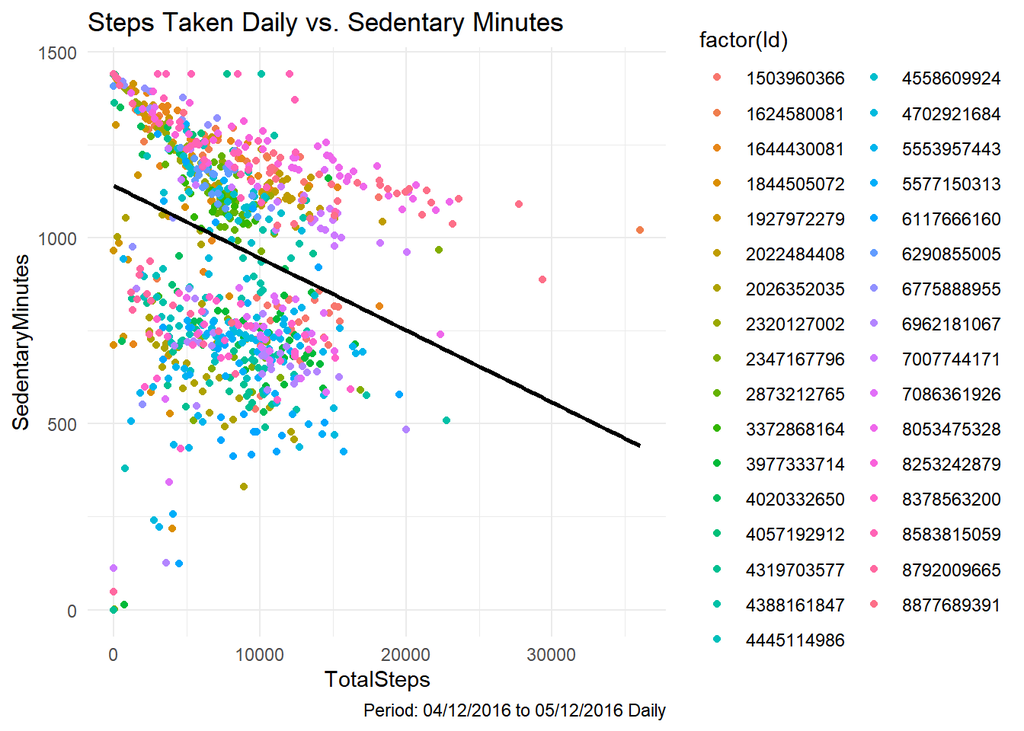

```r
ggplot(data = daily_activity_B, aes(x = TotalSteps, y = SedentaryMinutes, color = factor(Id))) + #replace with A and caption diff
  geom_point() +
  geom_smooth(method = "lm", se = FALSE, color = "black") +  # Adds a linear regression line
 # facet_wrap(~ Id, scales = "fixed") +  #add this line if gusto hiwahiwalay per unique id
  labs(
    title = "Steps Taken Daily vs. Sedentary Minutes",
    caption = "Period: 04/12/2016 to 05/12/2016 Daily" ) + #if B
    #caption = "Period: 03/11/2016 to 04/12/2016 Daily") + #if A
  theme_minimal()
```

####Relationship bet. minutesofsleep & time in bed:

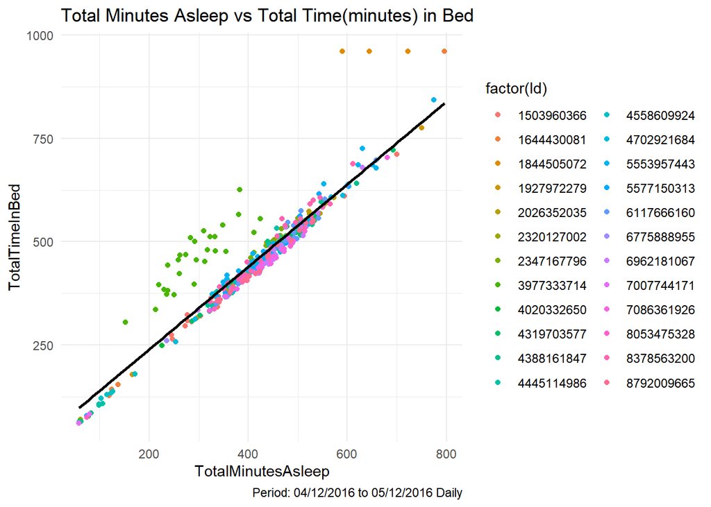

```r
ggplot(data=sleep_day_B, aes(x=TotalMinutesAsleep, y=TotalTimeInBed, color=factor(Id))) +
  geom_point() +
  geom_smooth(method = "lm", se = FALSE, color = "black") +  # Adds a linear regression line
  #facet_wrap(~ Id, scales = "fixed") +  #add this line if gusto hiwahiwalay per unique id
  labs(
    title="Total Minutes Asleep vs Total Time(minutes) in Bed",
    caption="Period: 04/12/2016 to 05/12/2016 Daily"
  ) +
  theme_minimal()
```

###DAILY-MERGE

```r
daily_merged_B <- merge(sleep_day_B,
                        daily_activity_B,
                        by.x = c("Id", "SleepDay"),  # Columns in sleep_day_B
                        by.y = c("Id", "ActivityDate"),  # Columns in daily_activity_B
                        all = TRUE)  # Keep all rows from both data frames

daily_merged_B <- daily_merged_B %>%
  rename(Date = SleepDay)

write.csv(daily_merged_B, "D:/Users/rjlde/Documents/+STUDY FILES+/2025 CASE STUDIES/CASE STUDY 2/RPROJ/CSV/CLEANED/daily_merged_B.csv", row.names = FALSE)
```

####check new table

```r
head(daily_merged_B)
```

```
##           Id       Date TotalSleepRecords TotalMinutesAsleep TotalTimeInBed
## 1 1503960366 2016-04-12                 1                327            346
## 2 1503960366 2016-04-13                 2                384            407
## 3 1503960366 2016-04-14                NA                 NA             NA
## 4 1503960366 2016-04-15                 1                412            442
## 5 1503960366 2016-04-16                 2                340            367
## 6 1503960366 2016-04-17                 1                700            712
##   TotalSteps TotalDistance TrackerDistance LoggedActivitiesDistance
## 1      13162          8.50            8.50                        0
## 2      10735          6.97            6.97                        0
## 3      10460          6.74            6.74                        0
## 4       9762          6.28            6.28                        0
## 5      12669          8.16            8.16                        0
## 6       9705          6.48            6.48                        0
##   VeryActiveDistance ModeratelyActiveDistance LightActiveDistance
```

[output cut: 20 more lines]

```r
nrow(daily_merged_B)
```

```
## [1] 940
```

```r
n_distinct(daily_merged_B)
```

```
## [1] 940
```

####Relationship betweeen total steps and total minutes asleep

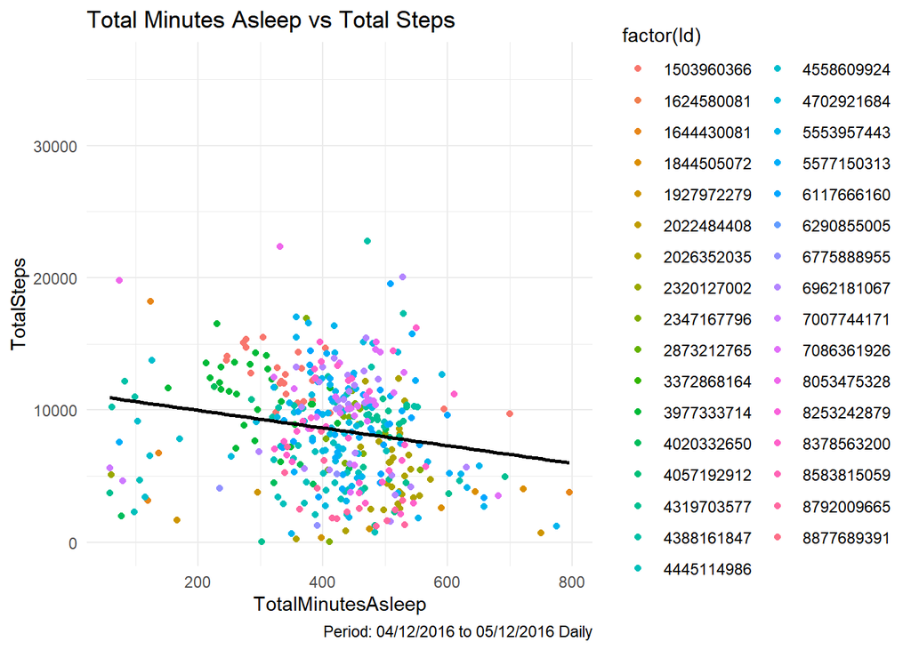

```r
ggplot(data=daily_merged_B, aes(x=TotalMinutesAsleep, y=TotalSteps, color=factor(Id)))+
  geom_point()+
  geom_smooth(method = "lm", se = FALSE, color = "black") +  # Adds a linear regression line
  #facet_wrap(~ Id, scales = "fixed", ncol = 5) #if want hiwahiwalay
  labs(
    title="Total Minutes Asleep vs Total Steps",
    caption="Period: 04/12/2016 to 05/12/2016 Daily"
  ) +
  theme_minimal()
```

####Very Active Minutes vs Sedentary Minutes

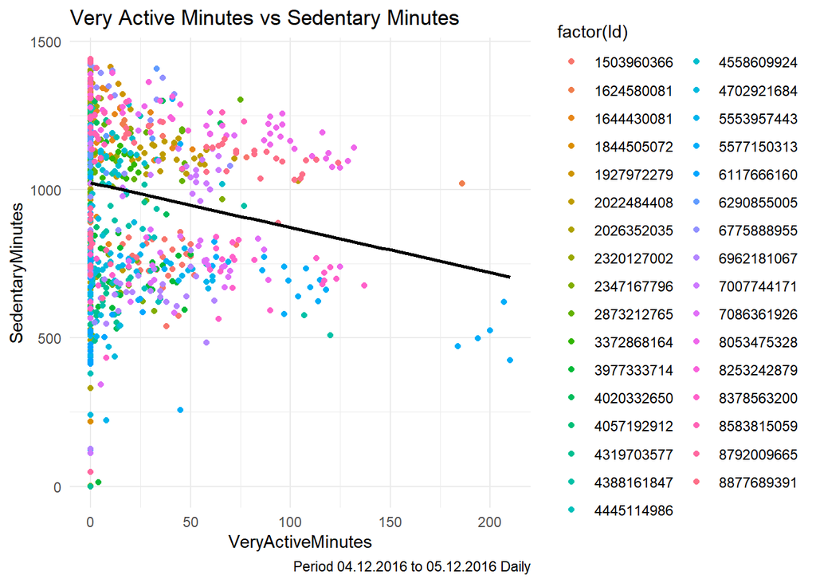

```r
ggplot(data = daily_merged_B, aes(x = VeryActiveMinutes, y = SedentaryMinutes, color=factor(Id))) +
  geom_point() +
  geom_smooth(method="lm", se = FALSE, color = "black") +
  labs(
    title = "Very Active Minutes vs Sedentary Minutes",
    caption ="Period 04.12.2016 to 05.12.2016 Daily"
  ) +
  theme_minimal()
```

####Activity_Type Minutes boxplot

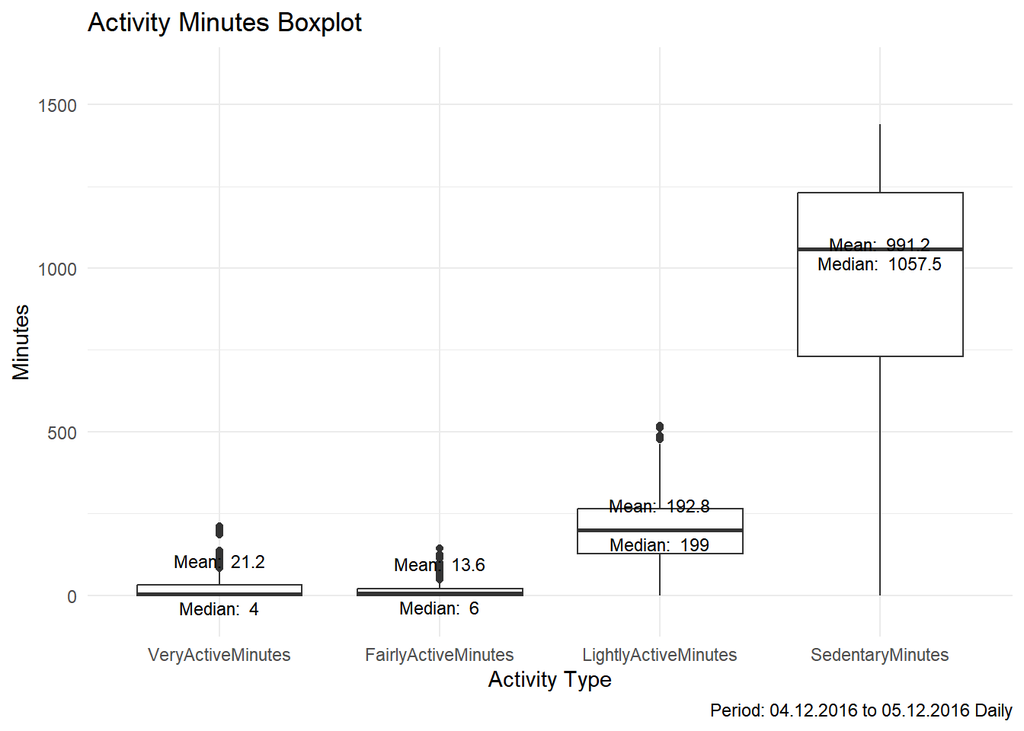

```r
activityMins_data <- daily_merged_B %>%
  select(VeryActiveMinutes,FairlyActiveMinutes,LightlyActiveMinutes,SedentaryMinutes)

# Reshape data from wide to long format
library(tidyr)
activity_data_long <- activityMins_data %>%
  gather(key = "ActivityType", value = "Minutes")

activity_data_long$ActivityType <- factor(activity_data_long$ActivityType,
                                          levels = c("VeryActiveMinutes", "FairlyActiveMinutes", "LightlyActiveMinutes", "SedentaryMinutes"))

# Create the boxplot
ggplot(activity_data_long, aes(x = ActivityType, y = Minutes)) +
  geom_boxplot() +
  stat_summary(fun.data = "mean_sdl", geom = "text",
               aes(label = paste("Mean: ", round(..y.., 1))),
               vjust = -1.5, size = 3) +  # Add mean label
  stat_summary(fun = "median", geom = "text",
               aes(label = paste("Median: ", round(..y.., 1))),
               vjust = 1.5, size = 3) +  # Add median label
  theme_minimal() +
  labs(title = "Activity Minutes Boxplot",
       x = "Activity Type",
       y = "Minutes",
       caption="Period: 04.12.2016 to 05.12.2016 Daily")
```

####Activity_Type Distance boxplot

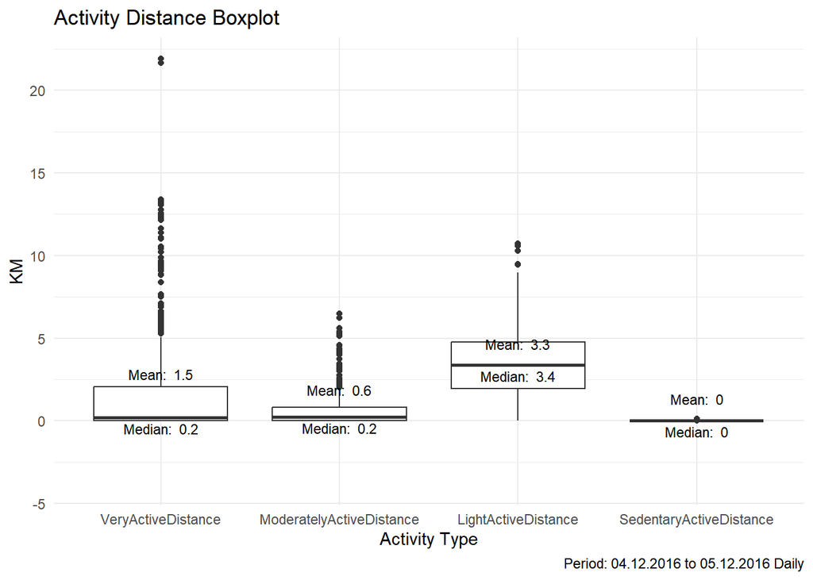

```r
activityDist_data <- daily_merged_B %>%
  select(VeryActiveDistance,ModeratelyActiveDistance,LightActiveDistance,SedentaryActiveDistance)

# Reshape data from wide to long format
library(tidyr)
activityD_data_long <- activityDist_data %>%
  gather(key = "ActivityType", value = "KM")

activityD_data_long$ActivityType <- factor(activityD_data_long$ActivityType,
                                          levels = c("VeryActiveDistance","ModeratelyActiveDistance","LightActiveDistance","SedentaryActiveDistance"))

# Create the boxplot
ggplot(activityD_data_long, aes(x = ActivityType, y = KM)) +
  geom_boxplot() +
  stat_summary(fun.data = "mean_sdl", geom = "text",
               aes(label = paste("Mean: ", round(..y.., 1))),
               vjust = -1.5, size = 3) +  # Add mean label
  stat_summary(fun = "median", geom = "text",
               aes(label = paste("Median: ", round(..y.., 1))),
               vjust = 1.5, size = 3) +  # Add median label
  theme_minimal() +
  labs(title = "Activity Distance Boxplot",
       x = "Activity Type",
       y = "KM",
       caption="Period: 04.12.2016 to 05.12.2016 Daily")
```

####Total Distance vs Total Steps

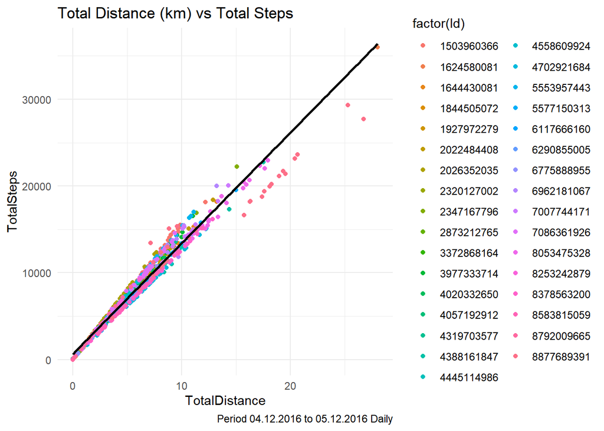

```r
ggplot(data = daily_merged_B, aes(x = TotalDistance, y = TotalSteps, color=factor(Id))) +
  geom_point() +
  geom_smooth(method="lm", se = FALSE, color = "black") +
  labs(
    title = "Total Distance (km) vs Total Steps",
    caption ="Period 04.12.2016 to 05.12.2016 Daily"
  ) +
  theme_minimal()
```

####Total Time Asleep vs Very Active MINUTES Faily Lightly sedentary (one-by-one)

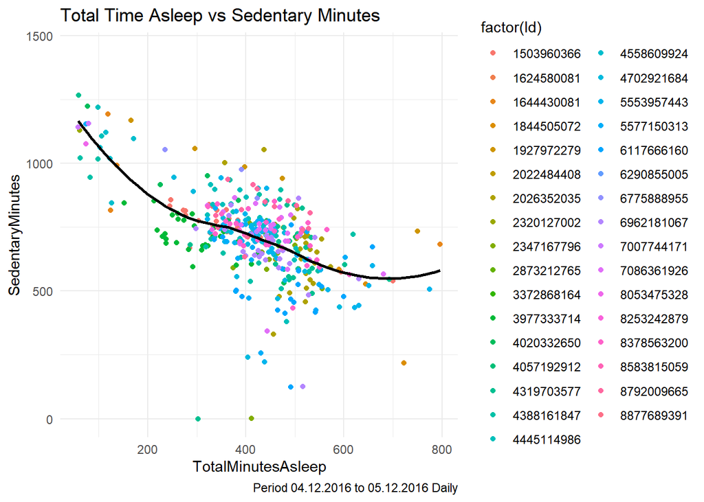

```r
ggplot(data = daily_merged_B, aes(x = TotalMinutesAsleep, y = SedentaryMinutes, color=factor(Id))) + #replace y axis
  geom_point() +
  geom_smooth(method="auto", se = FALSE, color = "black") +
  labs(
    #title = "Total Time Asleep vs Very Active Minutes",
    #title = "Total Time Asleep vs Faily Active Minutes",
    #title = "Total Time Asleep vs Lightly Active Minutes",
    title = "Total Time Asleep vs Sedentary Minutes",
    caption ="Period 04.12.2016 to 05.12.2016 Daily"
  ) +
  theme_minimal()
```

####Total Time Asleep vs Very Active MINUTES, Faily, Lightly, sedentary (in one)

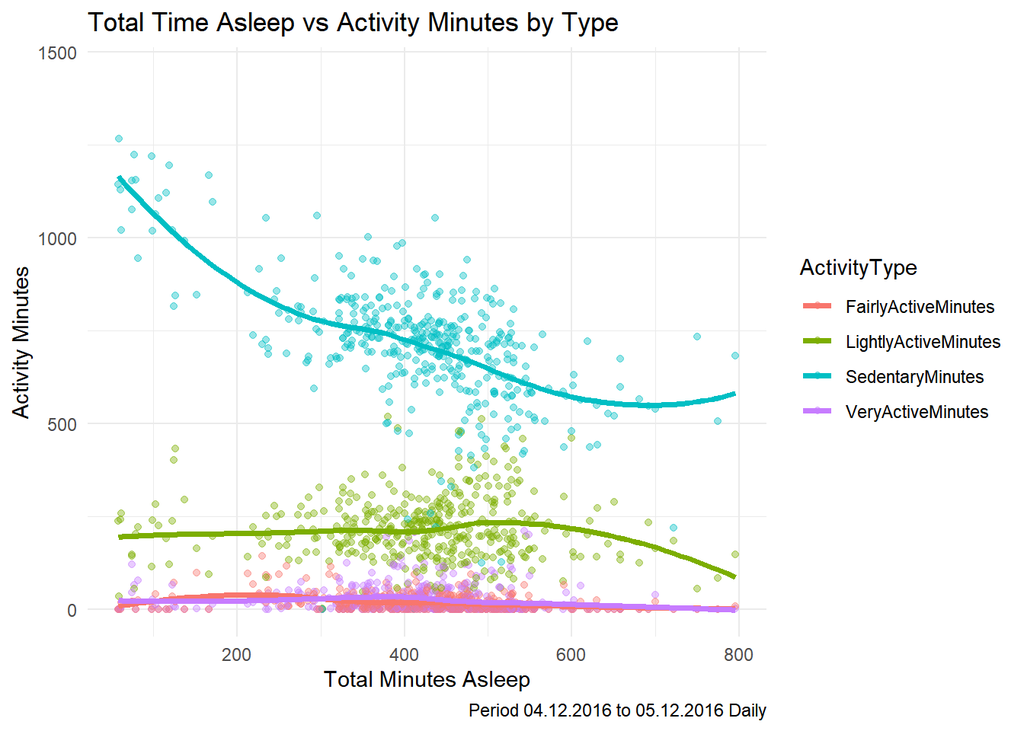

```r
activityM_long <- daily_merged_B %>%
  select(Id, TotalMinutesAsleep, VeryActiveMinutes, FairlyActiveMinutes, LightlyActiveMinutes, SedentaryMinutes) %>%
  pivot_longer(cols = c(VeryActiveMinutes, FairlyActiveMinutes, LightlyActiveMinutes, SedentaryMinutes),
               names_to = "ActivityType", values_to = "ActivityMinutes")

# Plot with reshaped data
ggplot(data = activityM_long, aes(x = TotalMinutesAsleep, y = ActivityMinutes, color = ActivityType)) +
  geom_point( alpha = 0.4) +
  geom_smooth(method = "auto", aes(color = ActivityType), size = 1.25, se = FALSE) +  # Color code the smoothed lines
  labs(
    title = "Total Time Asleep vs Activity Minutes by Type",
    caption = "Period 04.12.2016 to 05.12.2016 Daily",
    x = "Total Minutes Asleep",
    y = "Activity Minutes"
  ) +
  theme_minimal()
```

####Total Time Asleep vs Very Active DISTANCE Faily Lightly sedentary (one-by-one)

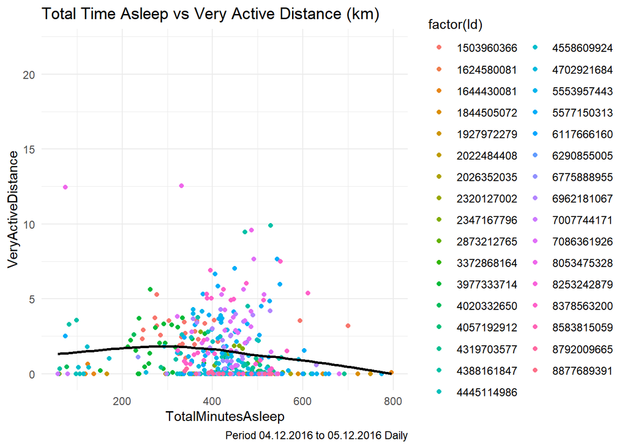

```r
ggplot(data = daily_merged_B, aes(x = TotalMinutesAsleep, y = VeryActiveDistance, color=factor(Id))) + #replace y axis
  geom_point() +
  geom_smooth(method="auto", se = FALSE, color = "black") +
  labs(
    title = "Total Time Asleep vs Very Active Distance (km)",
    #title = "Total Time Asleep vs Moderately Active Distance (km)",
    #title = "Total Time Asleep vs Lightly Active Distance (km)",
    #title = "Total Time Asleep vs Sedentary Active Distance (km)",
    caption ="Period 04.12.2016 to 05.12.2016 Daily"
  ) +
  theme_minimal()
```

####Total Time Asleep vs Very Active DISTANCE, Faily, Lightly, sedentary (in one)

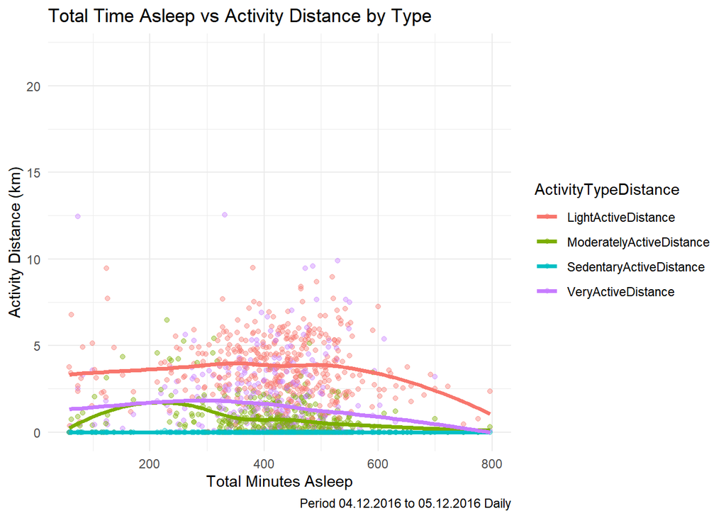

```r
activityD_long <- daily_merged_B %>%
  select(Id, TotalMinutesAsleep, VeryActiveDistance, ModeratelyActiveDistance, LightActiveDistance, SedentaryActiveDistance) %>%
  pivot_longer(cols = c(VeryActiveDistance, ModeratelyActiveDistance, LightActiveDistance, SedentaryActiveDistance),
               names_to = "ActivityTypeDistance", values_to = "ActivityDistance")

# Plot with reshaped data
ggplot(data = activityD_long, aes(x = TotalMinutesAsleep, y = ActivityDistance, color = ActivityTypeDistance)) +
  geom_point( alpha = 0.4) +
  geom_smooth(method = "auto", aes(color = ActivityTypeDistance), size = 1.25, se = FALSE) +  # Color code the smoothed lines
  labs(
    title = "Total Time Asleep vs Activity Distance by Type",
    caption = "Period 04.12.2016 to 05.12.2016 Daily",
    x = "Total Minutes Asleep",
    y = "Activity Distance (km)"
  ) +
  theme_minimal()
```

####Relationship betweeen total steps and total calories

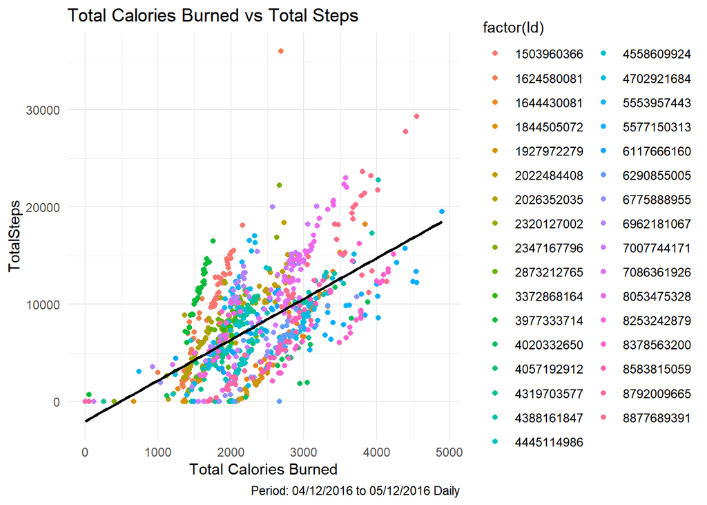

```r
ggplot(data=daily_merged_B, aes(x=Calories, y=TotalSteps, color=factor(Id)))+
  geom_point()+
  geom_smooth(method = "lm", se = FALSE, color = "black") +  # Adds a linear regression line
  #facet_wrap(~ Id, scales = "fixed", ncol = 5) #if want hiwahiwalay
  labs(
    title="Total Calories Burned vs Total Steps",
    caption="Period: 04/12/2016 to 05/12/2016 Daily",
    x = "Total Calories Burned"
  ) +
  theme_minimal()
```

####Total calories vs Very Active MINUTES Faily Lightly sedentary (one-by-one)

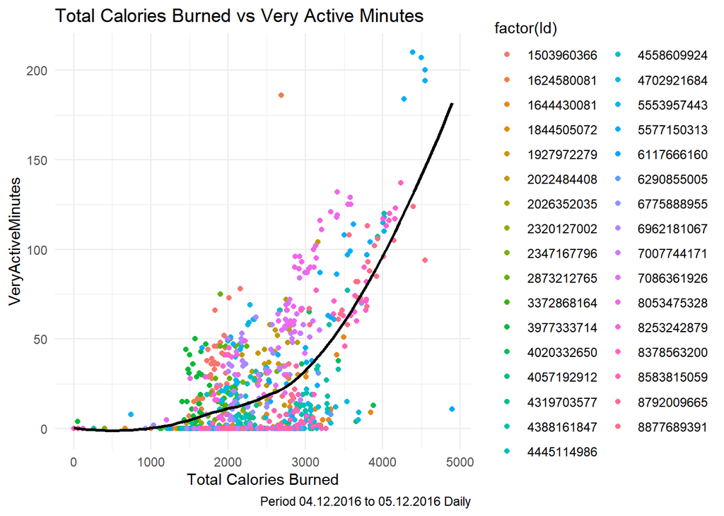

```r
ggplot(data = daily_merged_B, aes(x = Calories, y = VeryActiveMinutes, color=factor(Id))) + #replace y axis
  geom_point() +
  geom_smooth(method="auto", se = FALSE, color = "black") +
  labs(
    title = "Total Calories Burned vs Very Active Minutes",
    #title = "Total Calories Burned vs Faily Active Minutes",
    #title = "Total Calories Burned vs Lightly Active Minutes",
    #title = "Total Calories Burned vs Sedentary Minutes",
    caption ="Period 04.12.2016 to 05.12.2016 Daily",
    x = "Total Calories Burned"
  ) +
  theme_minimal()
```

####Total calories vs Very Active MINUTES, Faily, Lightly, sedentary (in one)

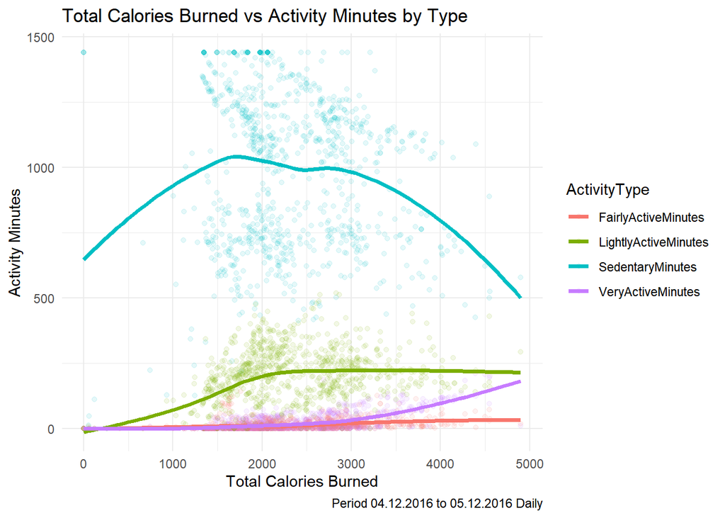

```r
activityCalM_long <- daily_merged_B %>%
  select(Id, Calories, VeryActiveMinutes, FairlyActiveMinutes, LightlyActiveMinutes, SedentaryMinutes) %>%
  pivot_longer(cols = c(VeryActiveMinutes, FairlyActiveMinutes, LightlyActiveMinutes, SedentaryMinutes),
               names_to = "ActivityType", values_to = "ActivityMinutes")

# Plot with reshaped data
ggplot(data = activityCalM_long, aes(x = Calories, y = ActivityMinutes, color = ActivityType)) +
  geom_point( alpha = 0.1) +
  geom_smooth(method = "auto", aes(color = ActivityType), size = 1.25, se = FALSE) +  # Color code the smoothed lines
  labs(
    title = "Total Calories Burned vs Activity Minutes by Type",
    caption = "Period 04.12.2016 to 05.12.2016 Daily",
    x = "Total Calories Burned",
    y = "Activity Minutes"
  ) +
  theme_minimal()
```

####Total CALORIES vs Very Active DISTANCE Faily Lightly sedentary (one-by-one)

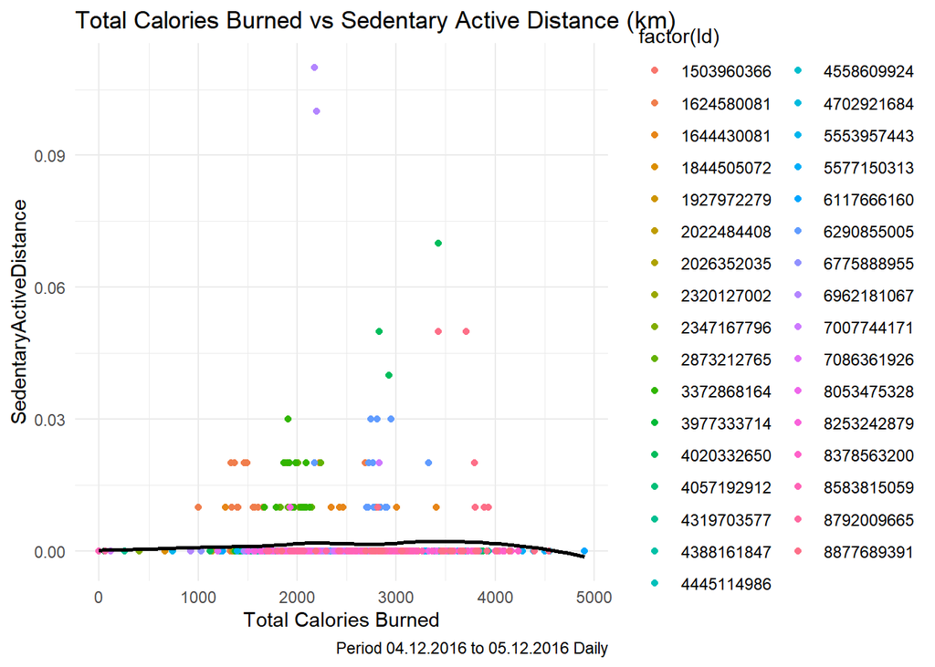

```r
ggplot(data = daily_merged_B, aes(x = Calories, y = SedentaryActiveDistance, color=factor(Id))) + #replace y axis
  geom_point() +
  geom_smooth(method="auto", se = FALSE, color = "black") +
  labs(
    #title = "Total Calories Burned vs Very Active Distance (km)",
    #title = "Total Calories Burned vs Moderately Active Distance (km)",
    #title = "Total Calories Burned vs Lightly Active Distance (km)",
    title = "Total Calories Burned vs Sedentary Active Distance (km)",
    caption ="Period 04.12.2016 to 05.12.2016 Daily",
    x = "Total Calories Burned"
  ) +
  theme_minimal()
```

####Total CALORIES vs Very Active DISTANCE, Faily, Lightly, sedentary (in one)

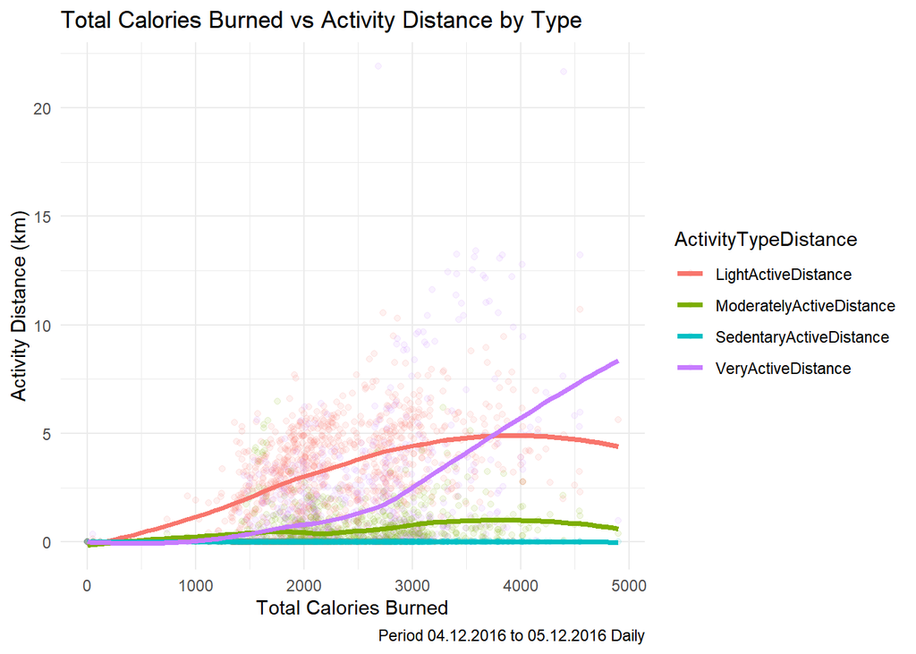

```r
activitycalD_long <- daily_merged_B %>%
  select(Id, Calories, VeryActiveDistance, ModeratelyActiveDistance, LightActiveDistance, SedentaryActiveDistance) %>%
  pivot_longer(cols = c(VeryActiveDistance, ModeratelyActiveDistance, LightActiveDistance, SedentaryActiveDistance),
               names_to = "ActivityTypeDistance", values_to = "ActivityDistance")

# Plot with reshaped data
ggplot(data = activitycalD_long, aes(x = Calories, y = ActivityDistance, color = ActivityTypeDistance)) +
  geom_point( alpha = 0.1) +
  geom_smooth(method = "auto", aes(color = ActivityTypeDistance), size = 1.25, se = FALSE) +  # Color code the smoothed lines
  labs(
    title = "Total Calories Burned vs Activity Distance by Type",
    caption = "Period 04.12.2016 to 05.12.2016 Daily",
    x = "Total Calories Burned",
    y = "Activity Distance (km)"
  ) +
  theme_minimal()
```

##HOURLY ###HOURLY-LOAD

```r
hourly_calories_B <- read.csv("D:/Users/rjlde/Documents/+STUDY FILES+/2025 CASE STUDIES/CASE STUDY 2/RPROJ/CSV/HOURLY/hourlyCalories_merged_4.12.16-5.12.16.csv", stringsAsFactors = FALSE)
hourly_Intensities_B <- read.csv("D:/Users/rjlde/Documents/+STUDY FILES+/2025 CASE STUDIES/CASE STUDY 2/RPROJ/CSV/HOURLY/hourlyIntensities_merged_4.12.16-5.12.16.csv", stringsAsFactors = FALSE)
hourly_steps_B <- read.csv("D:/Users/rjlde/Documents/+STUDY FILES+/2025 CASE STUDIES/CASE STUDY 2/RPROJ/CSV/HOURLY/hourlySteps_merged_4.12.16-5.12.16.csv", stringsAsFactors = FALSE)
```

Hourly Merge

```r
# First merge calories and intensities
hourly_activity <- merge(hourly_calories_B,
                         hourly_Intensities_B,
                         by = c("Id", "ActivityHour"),
                         all = TRUE)

# Then merge with steps
hourly_activity <- merge(hourly_activity,
                         hourly_steps_B,
                         by = c("Id", "ActivityHour"),
                         all = TRUE)

# Rename the datetime column
hourly_activity <- hourly_activity %>%
  rename(DateHour = ActivityHour)

write.csv(hourly_activity, "D:/Users/rjlde/Documents/+STUDY FILES+/2025 CASE STUDIES/CASE STUDY 2/RPROJ/CSV/CLEANED/hourly_activity_merged.csv", row.names = FALSE)
```

####HOURLY CLEAN head()

```r
head(hourly_activity)
```

```
##           Id              DateHour Calories TotalIntensity AverageIntensity
## 1 1503960366  4/12/2016 1:00:00 AM       61              8         0.133333
## 2 1503960366  4/12/2016 1:00:00 PM       66              6         0.100000
## 3 1503960366 4/12/2016 10:00:00 AM       99             29         0.483333
## 4 1503960366 4/12/2016 10:00:00 PM       65              9         0.150000
## 5 1503960366 4/12/2016 11:00:00 AM       76             12         0.200000
## 6 1503960366 4/12/2016 11:00:00 PM       81             21         0.350000
##   StepTotal
## 1       160
## 2       221
## 3       676
## 4        89
## 5       360
## 6       338
```

```r
#Findings - ActivityDate is chr not datetime format
```

```r
n_distinct(hourly_activity)
```

```
## [1] 22099
```

####Clean -> remove duplicated rows:

```r
hourly_activity <- hourly_activity[!duplicated(hourly_activity), ]
#no duplicated values found
```

Handle missing values:

```r
colSums(is.na(hourly_activity))
```

```
##               Id         DateHour         Calories   TotalIntensity
##                0                0                0                0
## AverageIntensity        StepTotal
##                0                0
```

```r
#no missing values found
```

Convert data types:

```r
library(lubridate)

# Convert DateHour to POSIXct format (for "MM/DD/YYYY h:mm:ss AM/PM")
hourly_activity$DateHour <- mdy_hms(hourly_activity$DateHour)

# Check the result
head(hourly_activity$DateHour)
```

```
## [1] "2016-04-12 01:00:00 UTC" "2016-04-12 13:00:00 UTC"
## [3] "2016-04-12 10:00:00 UTC" "2016-04-12 22:00:00 UTC"
## [5] "2016-04-12 11:00:00 UTC" "2016-04-12 23:00:00 UTC"
```

Quick Summary Stats:

```r
summary_hourly_activity <- hourly_activity %>%
    summary()

print(summary_hourly_activity)
```

```
##        Id               DateHour                         Calories
##  Min.   :1.504e+09   Min.   :2016-04-12 00:00:00.00   Min.   : 42.00
##  1st Qu.:2.320e+09   1st Qu.:2016-04-19 01:00:00.00   1st Qu.: 63.00
##  Median :4.445e+09   Median :2016-04-26 06:00:00.00   Median : 83.00
##  Mean   :4.848e+09   Mean   :2016-04-26 11:46:42.58   Mean   : 97.39
##  3rd Qu.:6.962e+09   3rd Qu.:2016-05-03 19:00:00.00   3rd Qu.:108.00
##  Max.   :8.878e+09   Max.   :2016-05-12 15:00:00.00   Max.   :948.00
##  TotalIntensity   AverageIntensity   StepTotal
##  Min.   :  0.00   Min.   :0.0000   Min.   :    0.0
##  1st Qu.:  0.00   1st Qu.:0.0000   1st Qu.:    0.0
##  Median :  3.00   Median :0.0500   Median :   40.0
##  Mean   : 12.04   Mean   :0.2006   Mean   :  320.2
##  3rd Qu.: 16.00   3rd Qu.:0.2667   3rd Qu.:  357.0
##  Max.   :180.00   Max.   :3.0000   Max.   :10554.0
```

SAVE Quick Summary Stats:

```r
write.csv(summary_hourly_activity, "D:/Users/rjlde/Documents/+STUDY FILES+/2025 CASE STUDIES/CASE STUDY 2/RPROJ/CSV/CLEANED/summary_hourly_activity_merged.csv", row.names = FALSE)
```

###HOURLY-EXPLORATION & VISUALIZATION ####Separate Date and Time

```r
hourly_activity_timed <- hourly_activity %>%
  mutate(
    Date = as.Date(DateHour),   # Extract the date part
    Time = format(DateHour, "%H:%M:%S")   # Extract the time part (in HH:MM:SS format)
  )

hourly_activity_timed$Time <- as_hms(hourly_activity_timed$Time)
```

check

```r
# Check the result
head(hourly_activity_timed)
```

```
##           Id            DateHour Calories TotalIntensity AverageIntensity
## 1 1503960366 2016-04-12 01:00:00       61              8         0.133333
## 2 1503960366 2016-04-12 13:00:00       66              6         0.100000
## 3 1503960366 2016-04-12 10:00:00       99             29         0.483333
## 4 1503960366 2016-04-12 22:00:00       65              9         0.150000
## 5 1503960366 2016-04-12 11:00:00       76             12         0.200000
## 6 1503960366 2016-04-12 23:00:00       81             21         0.350000
##   StepTotal       Date     Time
## 1       160 2016-04-12 01:00:00
## 2       221 2016-04-12 13:00:00
## 3       676 2016-04-12 10:00:00
## 4        89 2016-04-12 22:00:00
## 5       360 2016-04-12 11:00:00
## 6       338 2016-04-12 23:00:00
```

####PER HOUR total STEPS

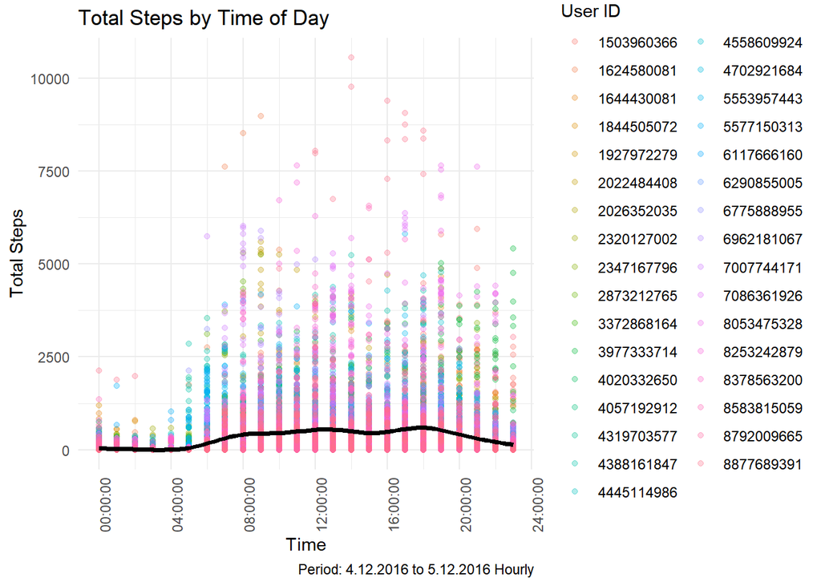

```r
ggplot(hourly_activity_timed, aes(x = Time, y = StepTotal, color = factor(Id))) +
  geom_point(alpha = 0.3) +
  geom_smooth(method = "auto", size = 1.25, color = "black", se = FALSE) +
  labs(
    title = "Total Steps by Time of Day",
    x = "Time",
    y = "Total Steps",
    color = "User ID",
    caption = "Period: 4.12.2016 to 5.12.2016 Hourly"
  ) +
  theme_minimal() +
  theme(
    axis.text.x = element_text(angle = 90, hjust = 1)  # Rotate x-axis labels by 90 degrees
  )
```

####PER HOUR total INTENSITIES

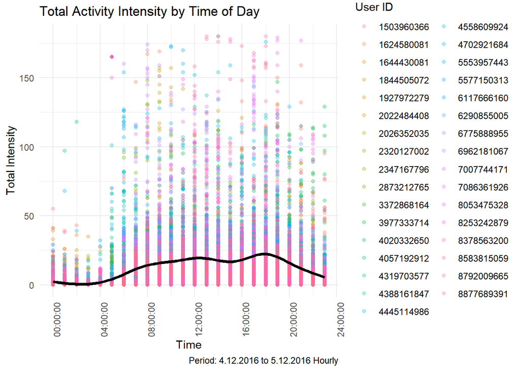

```r
ggplot(hourly_activity_timed, aes(x = Time, y = TotalIntensity, color = factor(Id))) +
  geom_point(alpha = 0.3) +
  geom_smooth(method = "auto", size = 1.25, color = "black", se = FALSE) +
  labs(
    title = "Total Activity Intensity by Time of Day",
    x = "Time",
    y = "Total Intensity",
    color = "User ID",
    caption = "Period: 4.12.2016 to 5.12.2016 Hourly"
  ) +
  theme_minimal() +
  theme(
    axis.text.x = element_text(angle = 90, hjust = 1)  # Rotate x-axis labels by 90 degrees
  )
```

####PER HOUR total CALORIES

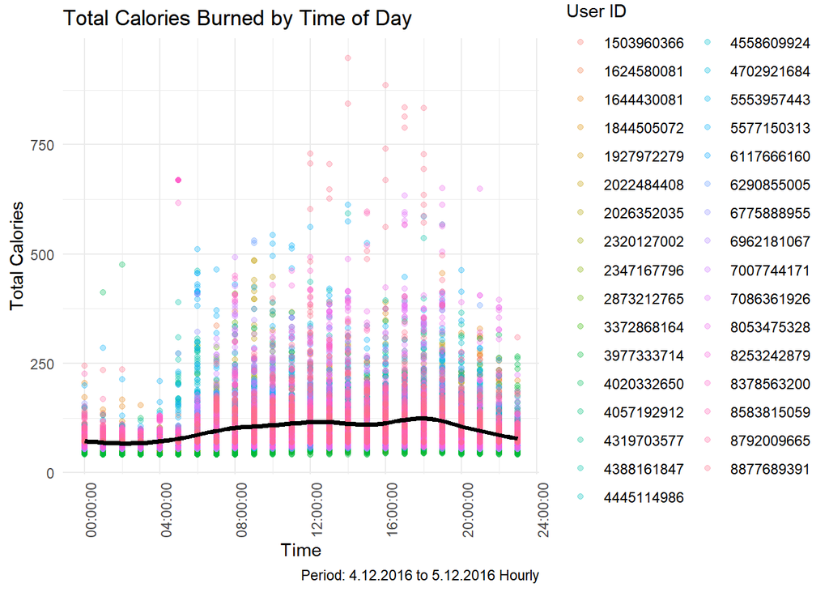

```r
ggplot(hourly_activity_timed, aes(x = Time, y = Calories, color = factor(Id))) +
  geom_point(alpha = 0.3) +
  geom_smooth(method = "auto", size = 1.25, color = "black", se = FALSE) +
  labs(
    title = "Total Calories Burned by Time of Day",
    x = "Time",
    y = "Total Calories",
    color = "User ID",
    caption = "Period: 4.12.2016 to 5.12.2016 Hourly"
  ) +
  theme_minimal() +
  theme(
    axis.text.x = element_text(angle = 90, hjust = 1)  # Rotate x-axis labels by 90 degrees
  )
```

###MINUTE - LOAD HEART RATE

```r
secs_heartRate <- read.csv("D:/Users/rjlde/Documents/+STUDY FILES+/2025 CASE STUDIES/CASE STUDY 2/RPROJ/CSV/SECOND/heartrate_seconds_merged_4.12.16-5.12.16.csv", stringsAsFactors = FALSE)
```

####MINUTE CLEAN head()

```r
head(secs_heartRate)
```

```
##           Id                 Time Value
## 1 2022484408 4/12/2016 7:21:00 AM    97
## 2 2022484408 4/12/2016 7:21:05 AM   102
## 3 2022484408 4/12/2016 7:21:10 AM   105
## 4 2022484408 4/12/2016 7:21:20 AM   103
## 5 2022484408 4/12/2016 7:21:25 AM   101
## 6 2022484408 4/12/2016 7:22:05 AM    95
```

```r
#Findings - Time is chr not datetime format
```

remove duplicated rows:

```r
secs_heartRate <- secs_heartRate[!duplicated(secs_heartRate), ]
#no duplicated values found
```

Handle missing values:

```r
colSums(is.na(secs_heartRate))
```

```
##    Id  Time Value
##     0     0     0
```

```r
#no missing values found
```

Convert data types:

```r
library(lubridate)

# Convert Time to POSIXct format (for "MM/DD/YYYY hh:mm:ss AM/PM")
secs_heartRate$Time <- mdy_hms(secs_heartRate$Time)

# Check the result
head(secs_heartRate)
```

```
##           Id                Time Value
## 1 2022484408 2016-04-12 07:21:00    97
## 2 2022484408 2016-04-12 07:21:05   102
## 3 2022484408 2016-04-12 07:21:10   105
## 4 2022484408 2016-04-12 07:21:20   103
## 5 2022484408 2016-04-12 07:21:25   101
## 6 2022484408 2016-04-12 07:22:05    95
```

```r
n_distinct(secs_heartRate$Id)
```

```
## [1] 14
```

####add column taking hours

```r
secs_heartRate$Hour <- format(secs_heartRate$Time, "%H")
```

```r
head(secs_heartRate)
```

```
##           Id                Time Value Hour
## 1 2022484408 2016-04-12 07:21:00    97   07
## 2 2022484408 2016-04-12 07:21:05   102   07
## 3 2022484408 2016-04-12 07:21:10   105   07
## 4 2022484408 2016-04-12 07:21:20   103   07
## 5 2022484408 2016-04-12 07:21:25   101   07
## 6 2022484408 2016-04-12 07:22:05    95   07
```

group by hour and user id

```r
avg_hrtRate_per_user <- secs_heartRate %>%
  group_by(Id, Hour) %>%
  summarise(avg_heart_rate = mean(Value, na.rm = TRUE)) %>%
  ungroup()
```

[output not shown]

####PLOT heart rate by time-of-day

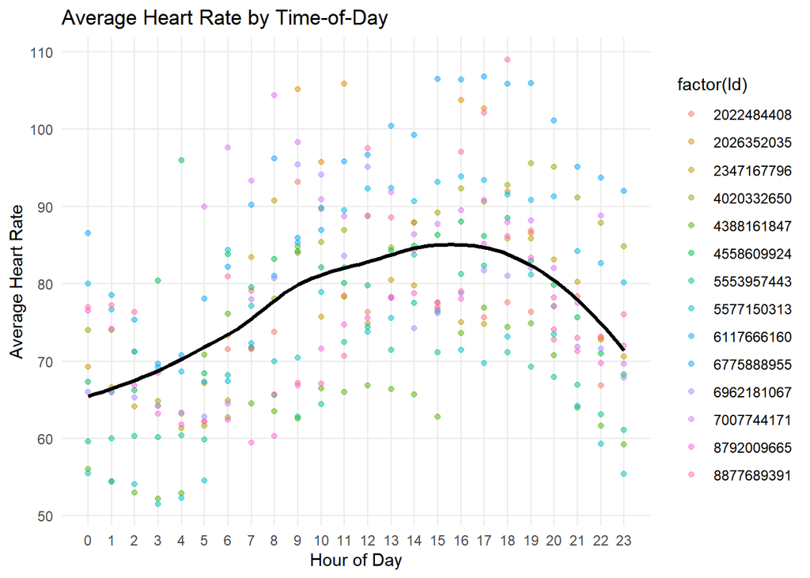

```r
ggplot(avg_hrtRate_per_user, aes(x = as.numeric(Hour), y = avg_heart_rate, color=factor(Id))) +
  geom_point(alpha = 0.5) +
  geom_smooth(aes(group = 1), method = "loess", se = FALSE, color = "black", size = 1.2) +
  scale_x_continuous(breaks = 0:23) +
  labs(title = "Average Heart Rate by Time-of-Day",
       x = "Hour of Day",
       y = "Average Heart Rate") +
  theme_minimal() +
  theme(panel.grid.minor = element_blank())
```